# Project: Investigate a Dataset (THE TMDB DATASET)

Background Study

Introduction

Research Questions

Data Wrangling

Data Cleaning

Exploratory Analysis

# Background:

The Movie Database (TMDB) is a community built movie and TV database. Every piece of data has been added by our amazing community dating back to 2008. TMDb's strong international focus and breadth of data is largely unmatched and something we're incredibly proud of. Put simply, we live and breathe community and that's precisely what makes us different.

Every year since 2008, the number of contributions to our database has increased. With over 400,000 developers and companies using our platform, TMDB has become a premiere source for metadata.

Along with extensive metadata for movies, TV shows and people, we also offer one of the best selections of high resolution posters and fanart. On average, over 1,000 images are added every single day.

We're international. While we officially support 39 languages we also have extensive regional data. Every single day TMDB is used in over 180 countries

# INTRODUCTION

This project explains and analyzes the TMDB Dataset having more than 10,000 rows and their different attributes or features. The project is focusing more on the Genres, and questions raised tells the story of the genres of movies and the relationship between the sales,budget allocated and the poularity of the movies. It also take cognisance of the raings and how well the vieweres vote to the the correlation between the revenue, budget,the poularity of the movies. This project made use of pandas library Package to evaluate and clean the data and the in-built function of pandas are used for expolatory analysis and visualization. The Exploratory analysis ,the revenue trend from year to year and the questions are answered.

# RESEARCH QUESTIONS

1.The Genres by the Total Revenue and Total Budget.

2.The Number Genres released.

3.The Genres of movies and the Runtime Duration.

4.Showing the Descriptive features of highly rated movies.

5.The Correlation Analysis of some of the different features.

7.The Change of Revenues And Budget over Years.

8.The Most popular Genres over the Years.

9.Which Genres are most popular from year to year.

10.What Genres are more popular and their Ratings.

# DATA WRANGLING

This process involves getting our data which has already being provided for us to use for the analysis.

The data was read using pandas DataFrame.

Extracted the first five rows to get the view of the data.

Displaying the number of rows and columns and the namesrespectively.

The number of missing values and the datatypes.

The display the statistical summary of numerical variables

# GENERAL PROPERTIES

```python
# import libary
#reading the datase
import numpy as np
import matplotlib.pyplot as plt
%matplotlib inline
import seaborn as sns
import pandas as pd
df_movie = pd.read_csv(r"C:\Users\User\Downloads\tmdb-movies.csv")
```

```python
# the first five rows
df_movie.head()
```

|  | id | imdb_id | popularity | budget | revenue | original_title | cast | homepage | director | tagline | ... | overview | runtime | genres | production_companies | release_date | vote_count | vote_average | release_year | budget_adj | revenue_adj |
| --- | --- | --- | --- | --- | --- | --- | --- | --- | --- | --- | --- | --- | --- | --- | --- | --- | --- | --- | --- | --- | --- |
| 0 | 135397 | tt0369610 | 32.985763 | 150000000 | 1513528810 | Jurassic World | Chris Pratt\|Bryce Dallas Howard\|Irrfan Khan\|Vi... | http://www.jurassicworld.com/ | Colin Trevorrow | The park is open. | ... | Twenty-two years after the events of Jurassic ... | 124 | Action\|Adventure\|Science Fiction\|Thriller | Universal Studios\|Amblin Entertainment\|Legenda... | 6/9/15 | 5562 | 6.5 | 2015 | 1.379999e+08 | 1.392446e+09 |
| 1 | 76341 | tt1392190 | 28.419936 | 150000000 | 378436354 | Mad Max: Fury Road | Tom Hardy\|Charlize Theron\|Hugh Keays-Byrne\|Nic... | http://www.madmaxmovie.com/ | George Miller | What a Lovely Day. | ... | An apocalyptic story set in the furthest reach... | 120 | Action\|Adventure\|Science Fiction\|Thriller | Village Roadshow Pictures\|Kennedy Miller Produ... | 5/13/15 | 6185 | 7.1 | 2015 | 1.379999e+08 | 3.481613e+08 |
| 2 | 262500 | tt2908446 | 13.112507 | 110000000 | 295238201 | Insurgent | Shailene Woodley\|Theo James\|Kate Winslet\|Ansel... | http://www.thedivergentseries.movie/#insurgent | Robert Schwentke | One Choice Can Destroy You | ... | Beatrice Prior must confront her inner demons ... | 119 | Adventure\|Science Fiction\|Thriller | Summit Entertainment\|Mandeville Films\|Red Wago... | 3/18/15 | 2480 | 6.3 | 2015 | 1.012000e+08 | 2.716190e+08 |
| 3 | 140607 | tt2488496 | 11.173104 | 200000000 | 2068178225 | Star Wars: The Force Awakens | Harrison Ford\|Mark Hamill\|Carrie Fisher\|Adam D... | http://www.starwars.com/films/star-wars-episod... | J.J. Abrams | Every generation has a story. | ... | Thirty years after defeating the Galactic Empi... | 136 | Action\|Adventure\|Science Fiction\|Fantasy | Lucasfilm\|Truenorth Productions\|Bad Robot | 12/15/15 | 5292 | 7.5 | 2015 | 1.839999e+08 | 1.902723e+09 |
| 4 | 168259 | tt2820852 | 9.335014 | 190000000 | 1506249360 | Furious 7 | Vin Diesel\|Paul Walker\|Jason Statham\|Michelle ... | http://www.furious7.com/ | James Wan | Vengeance Hits Home | ... | Deckard Shaw seeks revenge against Dominic Tor... | 137 | Action\|Crime\|Thriller | Universal Pictures\|Original Film\|Media Rights ... | 4/1/15 | 2947 | 7.3 | 2015 | 1.747999e+08 | 1.385749e+09 |

5 rows × 21 columns

```python
# listing all the columns names in the dataset
print(df_movie.columns.values)
```

```
['id' 'imdb_id' 'popularity' 'budget' 'revenue' 'original_title' 'cast'
 'homepage' 'director' 'tagline' 'keywords' 'overview' 'runtime' 'genres'
 'production_companies' 'release_date' 'vote_count' 'vote_average'
 'release_year' 'budget_adj' 'revenue_adj']
```

```python
# to display  the number of rows and columns
df_movie.shape
```

```
(10866, 21)
```

```python
# to display the columns,the missing values and  the datatypes
df_movie.info()
```

```
<class 'pandas.core.frame.DataFrame'>
RangeIndex: 10866 entries, 0 to 10865
Data columns (total 21 columns):
 #   Column                Non-Null Count  Dtype
---  ------                --------------  -----
 0   id                    10866 non-null  int64
 1   imdb_id               10856 non-null  object
 2   popularity            10866 non-null  float64
 3   budget                10866 non-null  int64
 4   revenue               10866 non-null  int64
 5   original_title        10866 non-null  object
 6   cast                  10790 non-null  object
 7   homepage              2936 non-null   object
 8   director              10822 non-null  object
 9   tagline               8042 non-null   object
 10  keywords              9373 non-null   object
 11  overview              10862 non-null  object
 12  runtime               10866 non-null  int64
 13  genres                10843 non-null  object
 14  production_companies  9836 non-null   object
 15  release_date          10866 non-null  object
 16  vote_count            10866 non-null  int64
 17  vote_average          10866 non-null  float64
 18  release_year          10866 non-null  int64
 19  budget_adj            10866 non-null  float64
 20  revenue_adj           10866 non-null  float64
dtypes: float64(4), int64(6), object(11)
memory usage: 1.7+ MB
```

```python
# to display the statistical summary of numerical variables
df_movie.describe()
```

|  | id | popularity | budget | revenue | runtime | vote_count | vote_average | release_year | budget_adj | revenue_adj |
| --- | --- | --- | --- | --- | --- | --- | --- | --- | --- | --- |
| count | 10866.000000 | 10866.000000 | 1.086600e+04 | 1.086600e+04 | 10866.000000 | 10866.000000 | 10866.000000 | 10866.000000 | 1.086600e+04 | 1.086600e+04 |
| mean | 66064.177434 | 0.646441 | 1.462570e+07 | 3.982332e+07 | 102.070863 | 217.389748 | 5.974922 | 2001.322658 | 1.755104e+07 | 5.136436e+07 |
| std | 92130.136561 | 1.000185 | 3.091321e+07 | 1.170035e+08 | 31.381405 | 575.619058 | 0.935142 | 12.812941 | 3.430616e+07 | 1.446325e+08 |
| min | 5.000000 | 0.000065 | 0.000000e+00 | 0.000000e+00 | 0.000000 | 10.000000 | 1.500000 | 1960.000000 | 0.000000e+00 | 0.000000e+00 |
| 25% | 10596.250000 | 0.207583 | 0.000000e+00 | 0.000000e+00 | 90.000000 | 17.000000 | 5.400000 | 1995.000000 | 0.000000e+00 | 0.000000e+00 |
| 50% | 20669.000000 | 0.383856 | 0.000000e+00 | 0.000000e+00 | 99.000000 | 38.000000 | 6.000000 | 2006.000000 | 0.000000e+00 | 0.000000e+00 |
| 75% | 75610.000000 | 0.713817 | 1.500000e+07 | 2.400000e+07 | 111.000000 | 145.750000 | 6.600000 | 2011.000000 | 2.085325e+07 | 3.369710e+07 |
| max | 417859.000000 | 32.985763 | 4.250000e+08 | 2.781506e+09 | 900.000000 | 9767.000000 | 9.200000 | 2015.000000 | 4.250000e+08 | 2.827124e+09 |

# DATA CLEANING

A Lot of cleaning was done to prepare it for the expolatory process.

The dataset was checked for duplicates and only one duplicate was found.

The duplicate rows was dropped and also missing values was also discovered.

There were some columns that were needed for the analysis and a whole lot was dropped so we could foocus on the relevant data.

The columns budget and revenue was dropped and the other budget_adj and revenue_adj was chosen becaues in the dataset description it informs and shows the revenue and budget in terms of 2010 dollars accounting for inflation over time.

Two columns were renamed the budget_adj and the revenue_adj to budget and revenue.

The datatypes of the columns were changed from float64 to int64.

The overall descriptive analysis was extracted.

It was discovered thst some of the rows of the columns Runtime,Budget and Revenue had zeros values in them which did not reflect real time scenarios.

Those columns were replaced with np.nan and filled with the mean of the columns.

The genres column had its genres in a long string seperated by a character.

```python
# to get total duplicate values
df_movie.duplicated().sum()
```

```
1
```

```python
# to drop duplicate values
df_movie.drop_duplicates(inplace = True)
```

```python
# to re-check if it is dropped
df_movie.duplicated().sum()
```

```
0
```

```python
#Counting the Total Missing
df_movie.isnull().sum().sum()
```

```
13433
```

```python
# to check for missing values
df_movie.isnull().sum()
```

```
id                         0
imdb_id                   10
popularity                 0
budget                     0
revenue                    0
original_title             0
cast                      76
homepage                7929
director                  44
tagline                 2824
keywords                1493
overview                   4
runtime                    0
genres                    23
production_companies    1030
release_date               0
vote_count                 0
vote_average               0
release_year               0
budget_adj                 0
revenue_adj                0
dtype: int64
```

```python
# to drop missing rows
df_movie.dropna(inplace = True)
```

```python
# to re_check thw missing values or non nulls have been dropped
df_movie.isnull().sum()
```

```
id                      0
imdb_id                 0
popularity              0
budget                  0
revenue                 0
original_title          0
cast                    0
homepage                0
director                0
tagline                 0
keywords                0
overview                0
runtime                 0
genres                  0
production_companies    0
release_date            0
vote_count              0
vote_average            0
release_year            0
budget_adj              0
revenue_adj             0
dtype: int64
```

```python
# drop irrelevant columns not needed in my analysis
df_movie.drop(['imdb_id','homepage','tagline','keywords', 'overview','release_date','budget','revenue'],axis =1,inplace = True)
```

```python
#renaming columns
df_movie.rename(columns= {'budget_adj':'budget','revenue_adj':'revenue'},inplace = True)
```

```python
# to re-check if they are dropped
df_movie.head(1)
```

|  | id | popularity | original_title | cast | director | runtime | genres | production_companies | vote_count | vote_average | release_year | budget | revenue |
| --- | --- | --- | --- | --- | --- | --- | --- | --- | --- | --- | --- | --- | --- |
| 0 | 135397 | 32.985763 | Jurassic World | Chris Pratt\|Bryce Dallas Howard\|Irrfan Khan\|Vi... | Colin Trevorrow | 124 | Action\|Adventure\|Science Fiction\|Thriller | Universal Studios\|Amblin Entertainment\|Legenda... | 5562 | 6.5 | 2015 | 1.379999e+08 | 1.392446e+09 |

```python
# rechecking the data shape the number of rows and columns
df_movie.shape
```

```
(1992, 13)
```

```python
# changing of column dataypes from float to int
for column in ['budget','revenue']:
     if df_movie[column].dtype == 'float64':
        df_movie[column] = df_movie[column].astype('int64')
```

```python
#re_checking the datatypes to reflect the changes
df_movie.dtypes
```

```
id                        int64
popularity              float64
original_title           object
cast                     object
director                 object
runtime                   int64
genres                   object
production_companies     object
vote_count                int64
vote_average            float64
release_year              int64
budget                    int64
revenue                   int64
dtype: object
```

```python
# The overall statistics of the dataset
df_movie.describe()
```

|  | id | popularity | runtime | vote_count | vote_average | release_year | budget | revenue |
| --- | --- | --- | --- | --- | --- | --- | --- | --- |
| count | 1992.000000 | 1992.000000 | 1992.000000 | 1992.000000 | 1992.000000 | 1992.000000 | 1.992000e+03 | 1.992000e+03 |
| mean | 71652.152108 | 1.316763 | 106.040161 | 643.616968 | 6.178614 | 2007.796687 | 3.627376e+07 | 1.302391e+08 |
| std | 92355.883915 | 1.873563 | 29.234592 | 1092.355998 | 0.881955 | 7.549224 | 5.129783e+07 | 2.564338e+08 |
| min | 11.000000 | 0.000620 | 0.000000 | 10.000000 | 2.100000 | 1961.000000 | 0.000000e+00 | 0.000000e+00 |
| 25% | 9699.000000 | 0.384079 | 92.000000 | 51.000000 | 5.600000 | 2006.000000 | 0.000000e+00 | 0.000000e+00 |
| 50% | 35112.500000 | 0.774223 | 102.000000 | 210.000000 | 6.200000 | 2010.000000 | 1.524601e+07 | 2.806370e+07 |
| 75% | 83573.000000 | 1.538639 | 116.000000 | 688.250000 | 6.800000 | 2012.000000 | 5.064450e+07 | 1.393645e+08 |
| max | 414419.000000 | 32.985763 | 705.000000 | 9767.000000 | 8.300000 | 2015.000000 | 4.250000e+08 | 2.827124e+09 |

```python
#masking the columns to replace it with np.nan then fill with the mean of the columns
cols= ['runtime','budget','revenue']
df_movie=df_movie.mask(df_movie==0).fillna(df_movie.mean())
```

```python
# re -checking the overal
df_movie.describe()
```

|  | id | popularity | runtime | vote_count | vote_average | release_year | budget | revenue |
| --- | --- | --- | --- | --- | --- | --- | --- | --- |
| count | 1992.000000 | 1992.000000 | 1992.000000 | 1992.000000 | 1992.000000 | 1992.000000 | 1.992000e+03 | 1.992000e+03 |
| mean | 71652.152108 | 1.316763 | 106.146627 | 643.616968 | 6.178614 | 2007.796687 | 4.623447e+07 | 1.659371e+08 |
| std | 92355.883915 | 1.873563 | 29.040570 | 1092.355998 | 0.881955 | 7.549224 | 4.659086e+07 | 2.446051e+08 |
| min | 11.000000 | 0.000620 | 5.000000 | 10.000000 | 2.100000 | 1961.000000 | 1.000000e+00 | 1.000000e+01 |
| 25% | 9699.000000 | 0.384079 | 92.000000 | 51.000000 | 5.600000 | 2006.000000 | 1.836508e+07 | 3.382971e+07 |
| 50% | 35112.500000 | 0.774223 | 102.000000 | 210.000000 | 6.200000 | 2010.000000 | 3.627376e+07 | 1.302391e+08 |
| 75% | 83573.000000 | 1.538639 | 116.000000 | 688.250000 | 6.800000 | 2012.000000 | 5.064450e+07 | 1.393645e+08 |
| max | 414419.000000 | 32.985763 | 705.000000 | 9767.000000 | 8.300000 | 2015.000000 | 4.250000e+08 | 2.827124e+09 |

CREATING A COPY OF THE DATASET

```python
# making a copy
df_movieGenre = df_movie.copy()
```

```python
#splitting the column genres to extract the individual genres
df_movieGenre['genres'] = df_movie.genres.str.split('|',expand = True)
```

```python
# using explode to incoporate it into the dataset
df_movieGenre.genres.str.split('|').explode().reset_index(drop = True)
```

```
0            Action
1            Action
2         Adventure
3            Action
4            Action
           ...
1987      Adventure
1988         Horror
1989         Comedy
1990    Documentary
1991         Action
Name: genres, Length: 1992, dtype: object
```

```python
# to the first five rows of the dataset
df_movieGenre.head()
```

|  | id | popularity | original_title | cast | director | runtime | genres | production_companies | vote_count | vote_average | release_year | budget | revenue |
| --- | --- | --- | --- | --- | --- | --- | --- | --- | --- | --- | --- | --- | --- |
| 0 | 135397 | 32.985763 | Jurassic World | Chris Pratt\|Bryce Dallas Howard\|Irrfan Khan\|Vi... | Colin Trevorrow | 124.0 | Action | Universal Studios\|Amblin Entertainment\|Legenda... | 5562 | 6.5 | 2015 | 137999939.0 | 1.392446e+09 |
| 1 | 76341 | 28.419936 | Mad Max: Fury Road | Tom Hardy\|Charlize Theron\|Hugh Keays-Byrne\|Nic... | George Miller | 120.0 | Action | Village Roadshow Pictures\|Kennedy Miller Produ... | 6185 | 7.1 | 2015 | 137999939.0 | 3.481613e+08 |
| 2 | 262500 | 13.112507 | Insurgent | Shailene Woodley\|Theo James\|Kate Winslet\|Ansel... | Robert Schwentke | 119.0 | Adventure | Summit Entertainment\|Mandeville Films\|Red Wago... | 2480 | 6.3 | 2015 | 101199955.0 | 2.716190e+08 |
| 3 | 140607 | 11.173104 | Star Wars: The Force Awakens | Harrison Ford\|Mark Hamill\|Carrie Fisher\|Adam D... | J.J. Abrams | 136.0 | Action | Lucasfilm\|Truenorth Productions\|Bad Robot | 5292 | 7.5 | 2015 | 183999919.0 | 1.902723e+09 |
| 4 | 168259 | 9.335014 | Furious 7 | Vin Diesel\|Paul Walker\|Jason Statham\|Michelle ... | James Wan | 137.0 | Action | Universal Pictures\|Original Film\|Media Rights ... | 2947 | 7.3 | 2015 | 174799923.0 | 1.385749e+09 |

```python
# getting the unique genres
df_movieGenre['genres'].unique()
```

```
array(['Action', 'Adventure', 'Western', 'Science Fiction', 'Drama',
       'Family', 'Comedy', 'Crime', 'War', 'Mystery', 'Fantasy',
       'Thriller', 'Romance', 'Horror', 'History', 'Documentary',
       'Animation', 'Music', 'TV Movie'], dtype=object)
```

SAVING THE DATAFRAME TO OUR WORKING DIRECTORY

```python
df_movieGenre.to_csv('cleanMovie.csv',index = False)
```

IMPORTING AND READING THE CSV

```python
df_tmdb =pd.read_csv('cleanMovie.csv')
```

# EXPLORATORY DATA ANALYSIS

QUESTION ONE:

What are the Genres that has Total Budget Allocation and Total Revenue Sales

OBSERVATIONS

This shows that Action,Dram and Adventure were allocated more budget in the movie production . While the Western and Tv Movie Genre had the lowest Budget Allocation. This shows the Genres and the Total Revenue made from box office sales. It shows that the Action movies clearly bring more Revenue,followed by the Adventure. While the Western and Tv Movie made the lowest revenue

```python
#Displaying the sum of the total revenue and total budget allocated
df_tmdb[['budget','revenue']].sum()
```

```
budget     9.209907e+10
revenue    3.305468e+11
dtype: float64
```

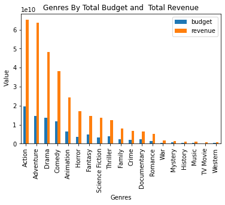

```python
#creating a barplot to display the total revenue and total budget of the gentes over the years
#using lambda to to get the two variables and the total sum  and grouping by the genres and sorting in descending
plt.figure(figsize=(10,10))
genresBY_Values =df_tmdb.groupby('genres').apply(lambda x:x[['budget','revenue']].sum()).sort_values(['revenue','budget'],ascending = [False,False])
genresBY_Values.plot.bar(title = 'Genres By Total Budget and  Total Revenue',xlabel='Genres',ylabel =' Value')
```

QUESTION TWO:

The Number OF Genres of Movies Released Over Years

OBSERVATIONS

The total nummber of Genres released It shows that Genre Dramas were released more from 1960 to 2010, having over 400,followed by Comedy and Action. Whilst the western had and Tv Movie had a minimal release of less than 10.

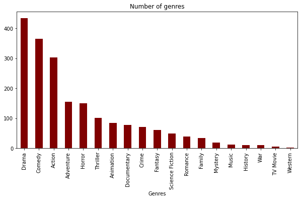

```python
# to get the number of genres of Movies released over years
#The value Counts of the genres was gotten
plt.figure(figsize=(10,5))
Count_of_genres =df_tmdb['genres'].value_counts()
Count_of_genres.plot.bar(title = 'Number of genres',xlabel='Genres',y ='Number of occurence',color = 'Maroon')
```

QUESTION THREE:

Which Genres have a higher Runtime For Movies

OBSERVATIONS

The mean runtime was derived using the groupby function to to get the mean runtime of each of the genres.

This shows that War Genre have the highest runtime duration over two hours for all the Movie Genres

Wilst the western came second in runtime duration, Having a longer runtime duration doesnt mean the genres are more popular.

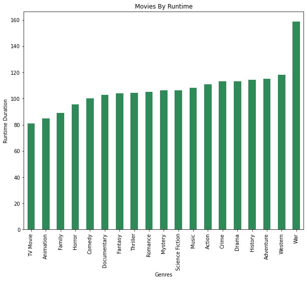

```python
# which genres of movies have the longest runtime
#the mean Runtime was derived and grouped by the genres
genresbyRuntime =df_tmdb.groupby('genres')['runtime'].mean().sort_values()
plt.figure(figsize =(10,8))
genresbyRuntime.plot.bar(title ='Movies By Runtime',xlabel = 'Genres',ylabel ='Runtime Duration', color = 'seagreen')
```

QUESTION FOUR:

What features Of Movie Genres Associated with high Rating

```python
# displaying the statistics summary of revenue
#the average rating is 50% which value is 6.2
df_tmdb.vote_average.describe()
```

```
count    1992.000000
mean        6.178614
std         0.881955
min         2.100000
25%         5.600000
50%         6.200000
75%         6.800000
max         8.300000
Name: vote_average, dtype: float64
```

```python
# Using a query to display the properties of  all movie genres that are greater or equal to the mean value of the variable vote average
df_tmdb.query('vote_average >=6.2')
```

|  | id | popularity | original_title | cast | director | runtime | genres | production_companies | vote_count | vote_average | release_year | budget | revenue |
| --- | --- | --- | --- | --- | --- | --- | --- | --- | --- | --- | --- | --- | --- |
| 0 | 135397 | 32.985763 | Jurassic World | Chris Pratt\|Bryce Dallas Howard\|Irrfan Khan\|Vi... | Colin Trevorrow | 124.0 | Action | Universal Studios\|Amblin Entertainment\|Legenda... | 5562 | 6.5 | 2015 | 1.379999e+08 | 1.392446e+09 |
| 1 | 76341 | 28.419936 | Mad Max: Fury Road | Tom Hardy\|Charlize Theron\|Hugh Keays-Byrne\|Nic... | George Miller | 120.0 | Action | Village Roadshow Pictures\|Kennedy Miller Produ... | 6185 | 7.1 | 2015 | 1.379999e+08 | 3.481613e+08 |
| 2 | 262500 | 13.112507 | Insurgent | Shailene Woodley\|Theo James\|Kate Winslet\|Ansel... | Robert Schwentke | 119.0 | Adventure | Summit Entertainment\|Mandeville Films\|Red Wago... | 2480 | 6.3 | 2015 | 1.012000e+08 | 2.716190e+08 |
| 3 | 140607 | 11.173104 | Star Wars: The Force Awakens | Harrison Ford\|Mark Hamill\|Carrie Fisher\|Adam D... | J.J. Abrams | 136.0 | Action | Lucasfilm\|Truenorth Productions\|Bad Robot | 5292 | 7.5 | 2015 | 1.839999e+08 | 1.902723e+09 |
| 4 | 168259 | 9.335014 | Furious 7 | Vin Diesel\|Paul Walker\|Jason Statham\|Michelle ... | James Wan | 137.0 | Action | Universal Pictures\|Original Film\|Media Rights ... | 2947 | 7.3 | 2015 | 1.747999e+08 | 1.385749e+09 |
| ... | ... | ... | ... | ... | ... | ... | ... | ... | ... | ... | ... | ... | ... |
| 1986 | 660 | 1.910465 | Thunderball | Sean Connery\|Claudine Auger\|Adolfo Celi\|Lucian... | Terence Young | 130.0 | Adventure | Eon Productions\|Metro-Goldwyn-Mayer (MGM) | 331 | 6.3 | 1965 | 7.612620e+07 | 9.771535e+08 |
| 1987 | 668 | 1.778746 | On Her Majesty's Secret Service | George Lazenby\|Diana Rigg\|Telly Savalas\|Gabrie... | Peter R. Hunt | 142.0 | Adventure | Eon Productions\|Metro-Goldwyn-Mayer (MGM)\|Danjaq | 258 | 6.4 | 1969 | 4.160985e+07 | 4.872780e+08 |
| 1988 | 948 | 1.198849 | Halloween | Donald Pleasence\|Jamie Lee Curtis\|P.J. Soles\|N... | John Carpenter | 91.0 | Horror | Compass International Pictures\|Falcon Internat... | 522 | 7.3 | 1978 | 1.002810e+06 | 2.339890e+08 |
| 1989 | 8469 | 1.157930 | Animal House | John Belushi\|Tim Matheson\|John Vernon\|Verna Bl... | John Landis | 109.0 | Comedy | Universal Pictures\|Oregon Film Factory\|Stage I... | 230 | 6.7 | 1978 | 9.025291e+06 | 4.713208e+08 |
| 1990 | 13963 | 0.064029 | The Last Waltz | Robbie Robertson\|Rick Danko\|Levon Helm\|Richard... | Martin Scorsese | 117.0 | Documentary | FM Productions\|Last Waltz Inc. | 33 | 8.0 | 1978 | 3.627376e+07 | 1.076189e+06 |

1053 rows × 13 columns

THE DISTRIBUTION OF THE VARIABLES IN THE DATASET

Univariate Exploration

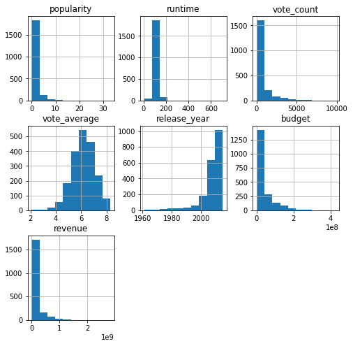

```python
# create histograms for analysis
df_tmdb.drop(['id'], axis=1).hist(figsize=(8,8));
```

```python
#the describtional stastistics
df_tmdb.describe()
```

|  | id | popularity | runtime | vote_count | vote_average | release_year | budget | revenue |
| --- | --- | --- | --- | --- | --- | --- | --- | --- |
| count | 1992.000000 | 1992.000000 | 1992.000000 | 1992.000000 | 1992.000000 | 1992.000000 | 1.992000e+03 | 1.992000e+03 |
| mean | 71652.152108 | 1.316763 | 106.146627 | 643.616968 | 6.178614 | 2007.796687 | 4.623447e+07 | 1.659371e+08 |
| std | 92355.883915 | 1.873563 | 29.040570 | 1092.355998 | 0.881955 | 7.549224 | 4.659086e+07 | 2.446051e+08 |
| min | 11.000000 | 0.000620 | 5.000000 | 10.000000 | 2.100000 | 1961.000000 | 1.000000e+00 | 1.000000e+01 |
| 25% | 9699.000000 | 0.384079 | 92.000000 | 51.000000 | 5.600000 | 2006.000000 | 1.836508e+07 | 3.382971e+07 |
| 50% | 35112.500000 | 0.774223 | 102.000000 | 210.000000 | 6.200000 | 2010.000000 | 3.627376e+07 | 1.302391e+08 |
| 75% | 83573.000000 | 1.538639 | 116.000000 | 688.250000 | 6.800000 | 2012.000000 | 5.064450e+07 | 1.393645e+08 |
| max | 414419.000000 | 32.985763 | 705.000000 | 9767.000000 | 8.300000 | 2015.000000 | 4.250000e+08 | 2.827124e+09 |

Displaying the presence of Outliers in popularity and runtime columns

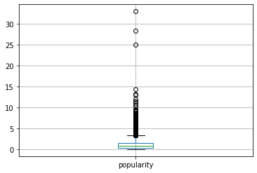

```python
# showing the presence of ouliers on s
# the popularity column
df_tmdb.boxplot(column ='popularity')
```

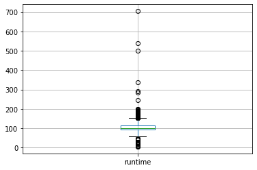

```python
#the presence of outliers
# the runtime column
df_tmdb.boxplot(column ='runtime')
```

OBSERVATIONS: Runtime has outliers

```python
# the correlation analysis
df_tmdb.corr()
```

|  | id | popularity | runtime | vote_count | vote_average | release_year | budget | revenue |
| --- | --- | --- | --- | --- | --- | --- | --- | --- |
| id | 1.000000 | 0.022330 | -0.015155 | -0.069752 | -0.066973 | 0.507116 | -0.136642 | -0.109818 |
| popularity | 0.022330 | 1.000000 | 0.220071 | 0.774226 | 0.298066 | 0.002262 | 0.456752 | 0.559553 |
| runtime | -0.015155 | 0.220071 | 1.000000 | 0.280477 | 0.240217 | -0.075793 | 0.242931 | 0.223345 |
| vote_count | -0.069752 | 0.774226 | 0.280477 | 1.000000 | 0.379345 | 0.006364 | 0.597076 | 0.701546 |
| vote_average | -0.066973 | 0.298066 | 0.240217 | 0.379345 | 1.000000 | -0.152250 | 0.110985 | 0.245365 |
| release_year | 0.507116 | 0.002262 | -0.075793 | 0.006364 | -0.152250 | 1.000000 | 0.011775 | -0.218961 |
| budget | -0.136642 | 0.456752 | 0.242931 | 0.597076 | 0.110985 | 0.011775 | 1.000000 | 0.610304 |
| revenue | -0.109818 | 0.559553 | 0.223345 | 0.701546 | 0.245365 | -0.218961 | 0.610304 | 1.000000 |

Bivariate Exploration

[output not shown]

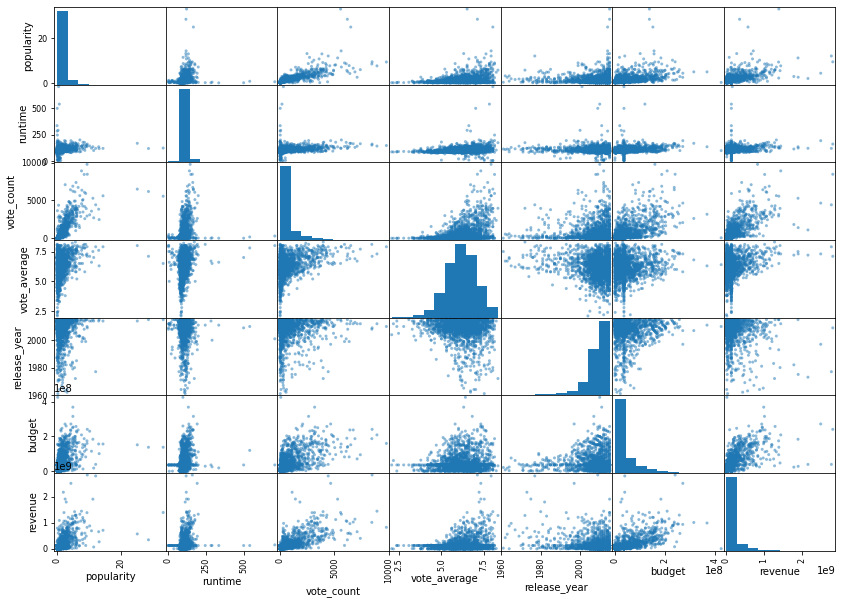

```python
#create scatter plots between each of the variables in the dataset
pd.plotting.scatter_matrix(df_tmdb.drop(['id'], axis=1), figsize=(14,10))
```

QUESTION FIVE :

5a.Showing the Correlation Analysis Of the

Runtime and Popularity

[figure not shown]

```python
#createscatterplot of popularity by runtime
plt.figure(figsize =(10,5))
plt.scatter(df_tmdb.runtime,df_tmdb.popularity)
plt.title('The Relationship between Popularity and Runtime')
plt.xlabel('Popularity')
plt.ylabel('Runtime')
```

5b: The correlation analysis of Vote_Count and Popularity

Observation

This is the relationship between the votecount and popularity.

It shows a postive correlation

From here we can deduce that Movies that are popular get a high votecount score

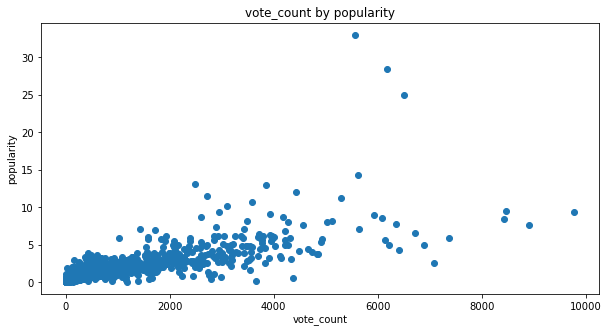

```python
#create scatterplot of vote_count by popularity
# defining a function
x ='vote_count'
y='popularity'
def scatter(x,y):
    #takes the variables x and y
    # realtionship between two variable x and y
    #the correlation analysis of vote_count by popularity
    plt.figure(figsize =(10,5))
    plt.scatter(x,y,data = df_tmdb)

scatter(x,y)
plt.title('{} by {}' .format(x,y))
plt.xlabel('{}'.format(x))
plt.ylabel('{}'.format(y))
```

5c: The correlation analysis of Vote Count and Budget

OBSERVATION

This is the relationship between the votecount and budget.

It shows a postive correlation but not so high

From here we can deduce that Movies Genres that are alloted fair rate of vote count by the budget amount allotted

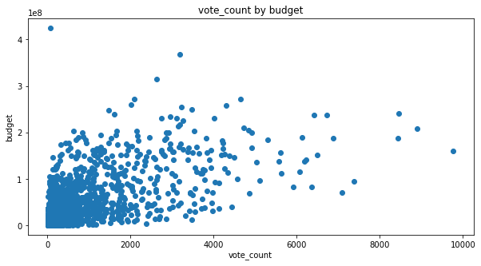

```python
#create scatterplot of vote_count by budget
#correlation Analysis of vote_count and Budget
y='budget'
scatter(x,y)
plt.title('{} by {}' .format(x,y))
plt.xlabel('{}'.format(x))
plt.ylabel('{}'.format(y))
```

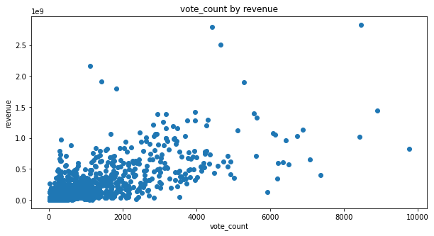

```python
#create scatterplot of vote_count by revenue
#correlation Analysis of voteCount and revenue
y = 'revenue'
scatter(x,y)
plt.title('{} by {}' .format(x,y))
plt.xlabel('{}'.format(x))
plt.ylabel('{}'.format(y))
```

5d:The Correlation Analysis of VoteCount and Revenue

OBSERVATIONS

This showing the relationship between the VoteCount and Revenue. The shows a postive correlation .It can be deduced viewers do give high votecount for Movie Genres that have high revenue

[figure not shown]

```python
#create scatterplot of popularity by revenue
#correlation Analysis of popularity and revenue
plt.figure(figsize =(10,5))
plt.scatter(df_tmdb.revenue,df_tmdb.popularity)
plt.title('The Relationship between Popularity and Revenue')
plt.xlabel('Popularity')
plt.ylabel('Revenue')
```

5f: Correlation Analysis Of Budget By Revenue

OBSERVATION

This is the relationship between the revenue and budget.

This is a postive Correlation

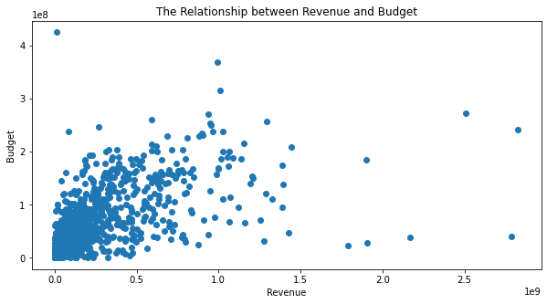

```python
#createscatterplot of revenue by budget
#correlation Analysis of revenue and Budget
plt.figure(figsize =(10,5))
plt.scatter(df_tmdb.revenue,df_tmdb.budget)
plt.title('The Relationship between Revenue and Budget')
plt.xlabel('Revenue')
plt.ylabel('Budget')
```

QUESTION SIX:

```python
#top 10 movies by Hgh Rating
#getting the top 10 from a long list of movie titles
#sorting by the vote_average
#using the orginal title as the index
top_10By_avgVote =df_tmdb[['original_title','vote_average']].head(10).sort_values\
(by ='vote_average',ascending = False)
top_10By_avgVote.reset_index(drop =True,inplace = True)
top_10By_avgVote.set_index('original_title',inplace = True)
top_10By_avgVote
```

| original_title | vote_average |
| --- | --- |
| Inside Out | 8.0 |
| The Martian | 7.6 |
| Star Wars: The Force Awakens | 7.5 |
| Furious 7 | 7.3 |
| The Revenant | 7.2 |
| Mad Max: Fury Road | 7.1 |
| Jurassic World | 6.5 |
| Minions | 6.5 |
| Insurgent | 6.3 |
| Terminator Genisys | 5.8 |

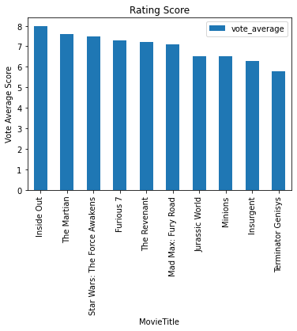

```python
#plotting to visualize
#the movie titles by the VoteAverage
plt.figure(figsize =(8,8))
top_10By_avgVote.plot.bar(title = 'Rating Score',xlabel ='MovieTitle',ylabel ='Vote Average Score')
```

QUESTION SEVEN:

The Change of Revenues And Budget over Years.

OBSERVATION

Technology improvement that have been incoporated in movie production have increased viewers going out and watching movies.

[output not shown]

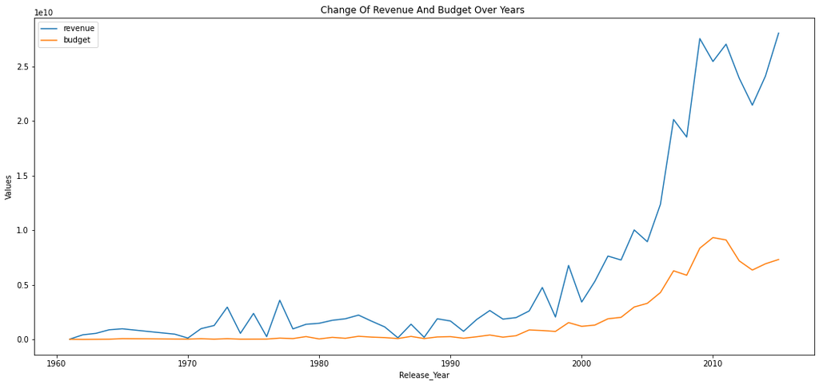

```python
#creating axis
#displaying the total revenue and budget and grouping by the release year
#using the aggregate function for the revenue and budget
figure,ax=plt.subplots(figsize=(18, 8))
df_tmdb.groupby('release_year') \
                .agg(revenue = ('revenue', 'sum'), \
                                    budget = ('budget',
                                    'sum')).plot(kind ='line',ax=ax)
ax.set(xlabel = 'Release_Year', ylabel = 'Values', title = 'Change Of Revenue And Budget Over Years ')
```

QUESTION EIGHT:

What Movie Titles are more Popular

OBSERVATIONS

```python
# displaying the ten rows of the variable original_title by popularity score
#sorting it by popularity in descending order
# reseting the default index and using the original_title as the index
most_pop_movie =df_tmdb[['original_title','popularity']].head(10).sort_values\
(by ='popularity',ascending = False)
most_pop_movie.reset_index(drop =True,inplace = True)
most_pop_movie.set_index('original_title',inplace = True)
```

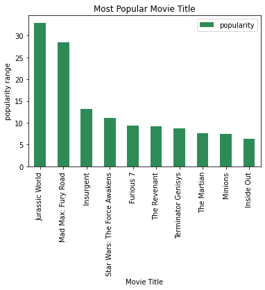

```python
#creating a barplot with the variables popularity and original _title
plt.figure(figsize =(8,8))
most_pop_movie.plot.bar(title ='Most Popular Movie Title'\
                        ,xlabel ='Movie Title',ylabel ='popularity range',color ='seagreen')
```

QUESTION NINE:

Which Genres are most popular from year to year.

[figure not shown]

```python
#creating the axis
#using the popularity values as count
#grouping by the genres and releaseyear over a period of yearsfrom 1960 to 2010
figure, ax = plt.subplots(figsize=(15,7))

df_tmdb.groupby(['release_year','genres']).popularity.count().unstack().plot\
(title ='Popularity of Genres over Years', xlabel ='Genres',ylabel = 'Rate of popularity',kind = 'line',ax =ax )

plt.show()
```

QUESTION TEN:

What Genres are more popular and their Ratings

```python
#extracting the variables from the DataFrame for this analysis
#displaying the values
extracted_var = df_tmdb[['genres','popularity','vote_average']].sort_values('vote_average',ascending = False)
```

[output not shown]

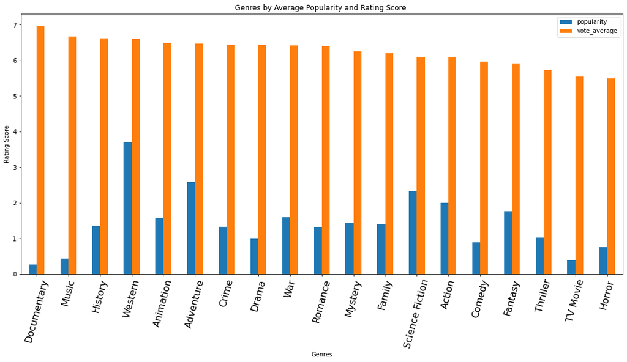

```python
#create figure object and axis
figure,ax=plt.subplots(figsize=(18, 8))


# Avergae popularity by genre
extracted_var.groupby(['genres']).mean().sort_values(["vote_average"], ascending=False).plot(kind="bar",  ax=ax)

ax.set(xlabel = 'Genres', ylabel = 'Rating Score', title = 'Genres by Average Popularity and Rating Score ')
plt.xticks(rotation=75,fontsize=16)
```

OBSERVATION

Documentaries are consistantly highly rated, but have a very low popularity score indicating that while they are not frequently watched, They are intensly enjoyed by those who do and those viewers do rate them highly.

# CONCLUSIONS

The revenue changed drastically over the year but showed an overall increase.

The 1960s accounts for the least budget allocated and revenue, while the 2010s accounts for the most.

The revenue of high revenue movie shows a strong positive correlation with budget and popularity, and a weak correlation with average voting and runtime.

More rutime duration doesnt conclude the movies are more popular to the viewers.

The most popular genre of the movie changed over the year and we can see that most movies gaines popularity after the year 2000.

The analysis does not state or imply that one change causes another based solely on a correlation.

That would require deeper statistical analysis that was not performed in this project.

LIMITATIONS

The Popularity and the runtime columns clearly have a large presence of outliers. As a result of the presence of outliers in the Popularity Column gettimg the mean popularity wouldnt give me a good statisticsal analysis.

The presence of zeros in the budget revenue ,budget_adj,revenue_adj and also in the runtime columns.

The Datasst contains so many missing values and in the cleaning process a lot of rows were dropped thus changing the shape of the Dataset.

REFERENCES

https://www.themoviedb.org/about

https://stackoverflow.com/questions/37787698/how-to-sort-pandas-dataframe-from-one-column

https://stackoverflow.com/questions/55319655/pandas-how-to-replace-zero-values-in-a-column-with-the-mean-of-that-column-for